# Modelos matemáticos

Taller de R

Xopre Rodríguez Gallego

15 de julio de 2025

# Introducción

En este documento se presentan ejemplos de modelos matemáticos discretos y continuos, utilizando R para resolver ecuaciones y visualizar resultados.

## Repaso

### Modelo discreto

$\begin{cases} x_{n+1} = f(x_n) \\ x_0 \ \text{dado} \end{cases}$

### Modelo continuo

$\begin{cases} y' = f(t,y) \\ y(0) \ \text{dado} \end{cases}$

### Modelo Lotka-Volterra

$\begin{cases} y_1' = f_1(y_1,y_2) \\ y_2' = f_2(y_1,y_2) \\ y(0) = (y_1(0), y_2(0)) \ \text{dado} \end{cases}$

# Modelos discretos

Definimos una función no lineal que depende de una constante `R`. Queremos estudiar el comportamiento de la iteración y encontrar sus puntos fijos.

```r
R = 2
f = function (x)  R*x/sqrt(1 + x/5)
```

Para mostrarla ahora, de una forma sencilla, podemos emplear `curve()`, del paquete base `graphics`:

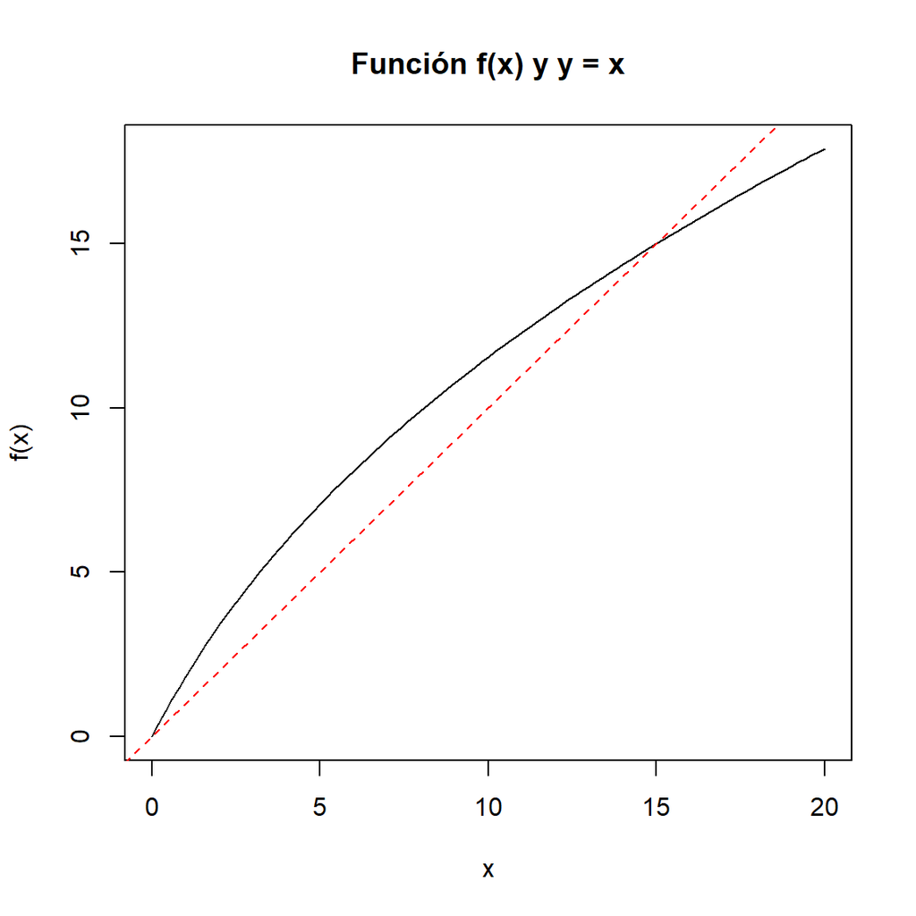

```r
curve(f(x), 0, 20, main = "Función f(x) y y = x")
abline(0, 1, lty = "dashed", col = "red")
```

Definimos ahora una función auxiliar para obtener los puntos fijos:

```r
fx = function (x) f(x) - x
```

Calculamos las raíces (puntos fijos) con dos métodos distintos, usando el paquete `rootSolve` y el paquete `pracma`:

```r
library(pracma)
xc = findzeros(fx, 0, 20)
print(xc)
```

```
## [1]  0 15
```

```r
library(rootSolve)
xc2 = uniroot.all(fx, c(0, 20))
xc2
```

```
## [1]  0 15
```

Comprobamos los valores obtenidos

```r
fx(xc2)
```

```
## [1] 0 0
```

```r
fx(xc)
```

```
## [1] 0 0
```

Analizamos la derivada en los puntos fijos para estudiar su estabilidad:

```r
library(Deriv)
fx_prime = Deriv(f, "x")
fx_prime
```

```
## function (x)
## {
##     .e1 <- 1 + x/5
##     R * (1 - 0.1 * (x/.e1))/sqrt(.e1)
## }
```

```r
fx_prime(xc2)
```

```
## [1] 2.000 0.625
```

Podemos, además, comprobar los tipos:

```r
class(f)
```

```
## [1] "function"
```

```r
class(fx_prime)
```

```
## [1] "function"
```

Realizamos una simulación de la evolución de la población, para 14 instantes temporales:

```r
N = 14
x = 1 # No hace falta x[1], aunque funciona
for (i in 2:N) {
  x[i] = f(x[i - 1])
}
cat("Para N = ", N, " se tiene x[", N, "] = ", x[N], sep = "")
```

```
## Para N = 14 se tiene x[14] = 14.80293
```

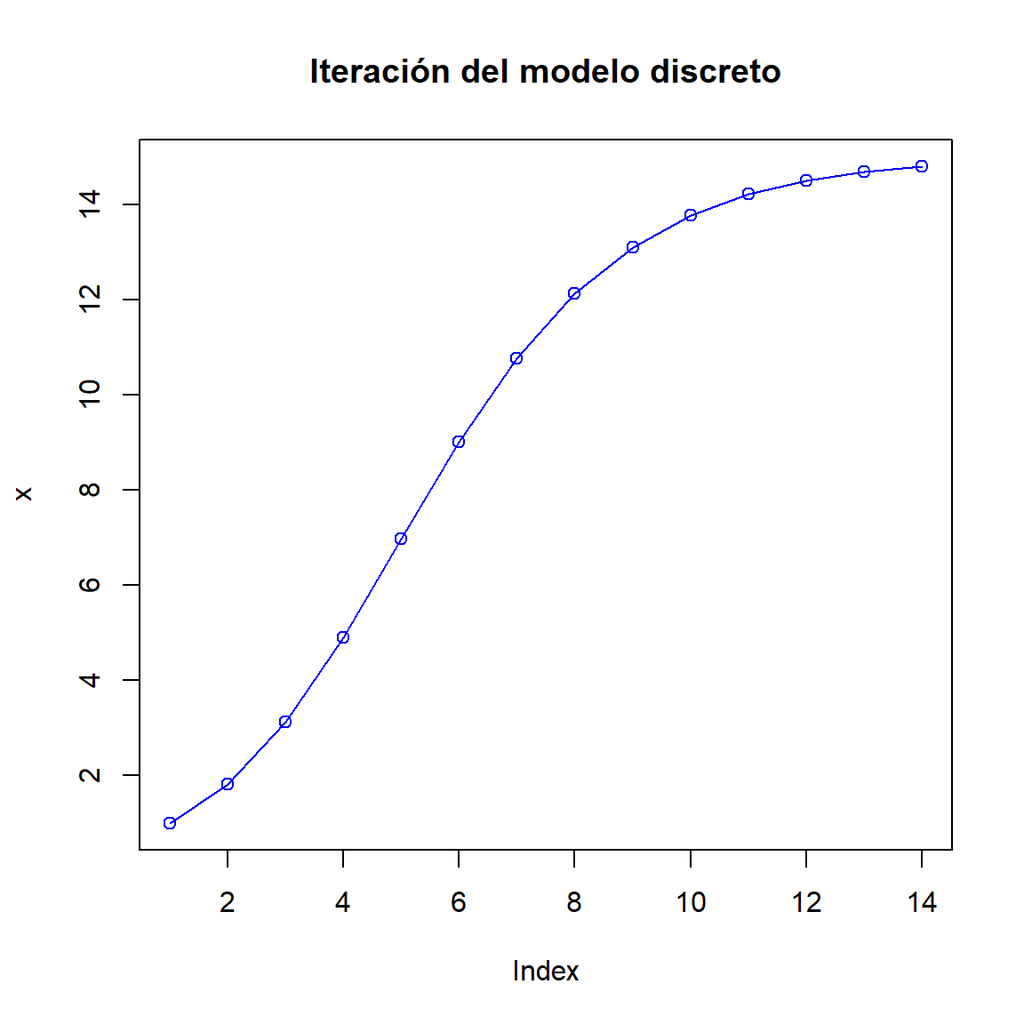

```r
plot(x, type = 'o', col = "blue", main = "Iteración del modelo discreto")
```

# Modelos continuos

Estudiamos un modelo continuo basado en una ecuación logística modificada. La función representa una tasa de cambio dependiente de la población `y`.

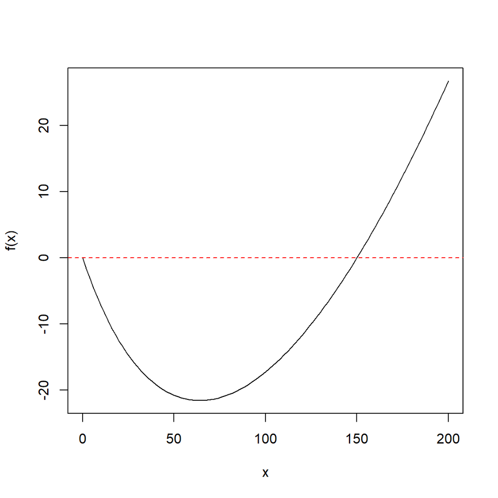

```r
f = function (y) -0.6*y*log(200 / (y + 50))
curve(f, 0, 200)
abline(h = 0, lty = "dashed", col = "red") # Nótese que deben ejecutarse a la vez
```

```r
xc = findzeros(f, 0, 200)
xc
```

```
## [1]   0 150
```

Comprobamos los resultados:

```r
f(xc)
```

```
## [1] 0 0
```

Calculamos la derivada de la función para analizar la estabilidad de los puntos fijos:

```r
fy = Deriv(f, "y")
fy(xc)
```

```
## [1] -0.8317766  0.4500000
```

Ahora resolvemos numéricamente la ecuación usando `ode45`:

```r
f_ode = function(t, y) -0.6*y*log(200 / (y + 50)) # Mismo tipo de función
sol = ode45(f_ode, t0 = 0, tfinal = 20, y0 = 1/250) # Sintaxis idéntica a Matlab
sol
```

```
## $t
##  [1]  0.0000000  0.2000000  0.7801805  1.4782664  2.2537595  3.1197156
##  [7]  4.0973610  5.2159489  6.5168767  8.0609373  9.9414392 12.3089572
## [13] 15.4160668 19.6391358 20.0000000
##
## $y
##  [1] 4.000000e-03 3.387011e-03 2.090480e-03 1.169740e-03 6.137344e-04
##  [6] 2.986888e-04 1.324888e-04 5.229039e-05 1.775984e-05 4.956244e-06
## [11] 1.076109e-06 1.872012e-07 5.108030e-08 7.411382e-08 5.489619e-08
```

Como vemos, la solución es un objeto con dos componentes: `t` y `y`, que representan el tiempo y la población, respectivamente. Podemos visualizar la solución:

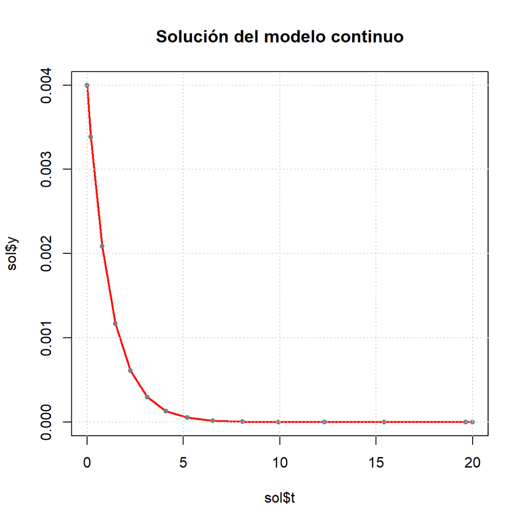

```r
plot(sol$t, sol$y, type = 'l', lwd = 2, col = "red",
     main = "Solución del modelo continuo")
points(sol$t, sol$y, pch = 20, col = "gray50")
grid()
```

## Avanzado

Podemos ahora repetir este procedimiento para varias condiciones iniciales, empleando un bucle `for`:

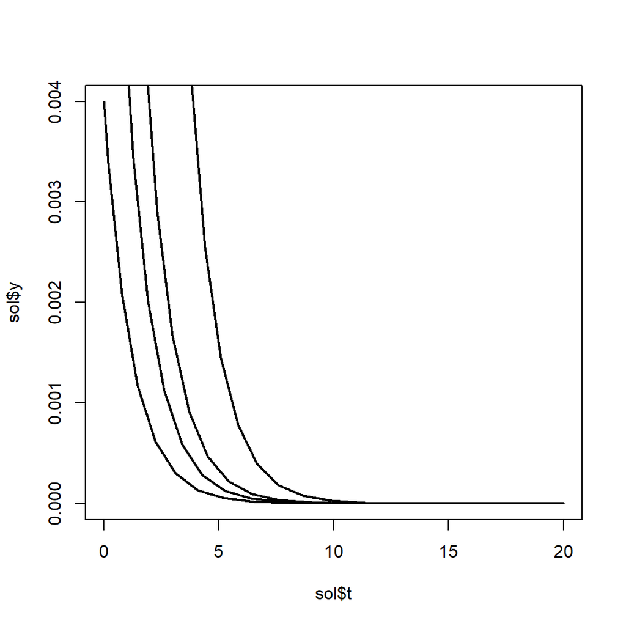

```r
plot(sol$t, sol$y, type = 'l', lwd = 2, col = "red") # Tenemos que incluir el inicial
for (y0 in c(1/250, 1/100, 1/50, 1/10)) {
  sol = ode45(f_ode, t0 = 0, tfinal = 20, y0 = y0)
  lines(sol$t, sol$y, lwd = 2)
}
```

# Modelo Lotka-Volterra

Estudiamos un sistema clásico depredador-presa con términos logísticos. Primero buscamos los puntos de equilibrio.

```r
LVmodnt = function(y) {
  dy1 = 0.1*(1 - y[1] / 100) - 0.01*y[2]
  dy2 = -0.05*(1 - y[2] / 150) + 0.001*y[1]
  c(dy1, dy2)
}

start_values <- c(y1 = 0, y2 = 0)
solnt = multiroot(f = LVmodnt, start = start_values)$root
solnt
```

```
##        y1        y2
## 48.275858  5.172414
```

Estudiamos ahora la estabilidad en los distintos puntos de equilibrio mediante la matriz Jacobiana y sus autovalores:

```r
LVmody = function(y) {
  dy1 = 0.1*y[1]*(1 - y[1]/100) - 0.01*y[1]*y[2]
  dy2 = -0.05*y[2]*(1 - y[2]/150) + 0.001*y[1]*y[2]
  c(dy1, dy2)
}

eigJ1 = eigen(jacobian(LVmody, c(0, 0)))
eigJ1
```

```
## eigen() decomposition
## $values
## [1]  0.10 -0.05
##
## $vectors
##      [,1] [,2]
## [1,]   -1    0
## [2,]    0   -1
```

```r
eigJ2 = eigen(jacobian(LVmody, c(100, 0)))$values
eigJ2
```

```
## [1] -0.10  0.05
```

```r
eigJ3 = eigen(jacobian(LVmody, c(0, 150)))
eigJ3
```

```
## eigen() decomposition
## $values
## [1] -1.40  0.05
##
## $vectors
##            [,1] [,2]
## [1,]  0.9946918    0
## [2,] -0.1028992    1
```

```r
eigJ4 = eigen(jacobian(LVmody, solnt))
eigJ4
```

```
## eigen() decomposition
## $values
## [1] -0.02327586+0.04326693i -0.02327586-0.04326693i
##
## $vectors
##                        [,1]                   [,2]
## [1,]  0.9946855+0.00000000i  0.9946855+0.00000000i
## [2,] -0.0515105-0.08914806i -0.0515105+0.08914806i
```

## Resolución del modelo Lotka-Volterra

Definimos condiciones iniciales y resolvemos el sistema en el intervalo deseado:

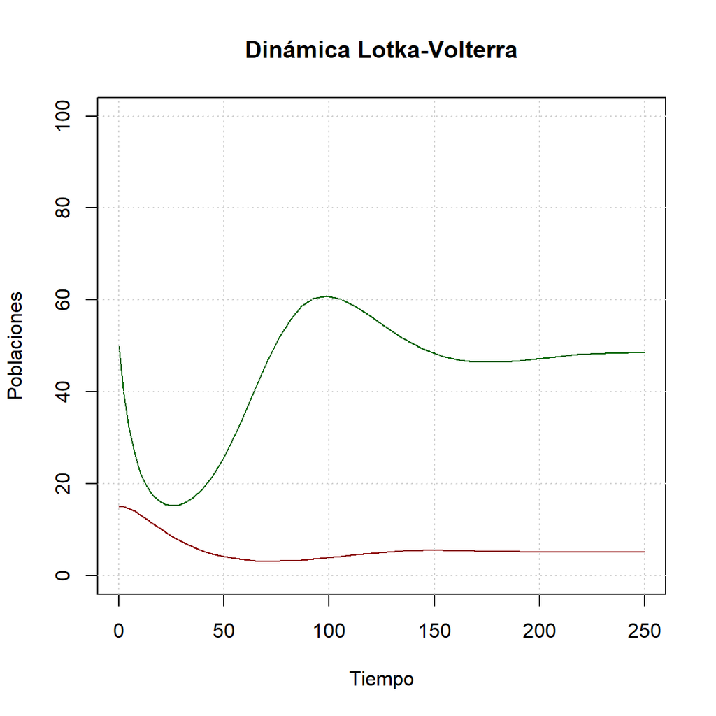

```r
y0 = c(50, 15)
tspan <- seq(0, 240, by = 2)

LVmod = function(t, y) {
  dy1 = 0.1*y[1]*(1 - y[1]/100) - 0.01*y[1]*y[2]
  dy2 = -0.05*y[2]*(1 - y[2]/150) + 0.001*y[1]*y[2]
  c(dy1, dy2)
}

sol = ode45(LVmod, 0, 250, y0)

plot(sol$t, sol$y[, 1], type = 'l', ylim = c(0, 100), col = "darkgreen",
     ylab = "Poblaciones", xlab = "Tiempo", main = "Dinámica Lotka-Volterra")
lines(sol$t, sol$y[, 2], col = "darkred")
grid()
```

# Mejora de la visualización con `ggplot2`

Volvemos al modelo continuo pero usamos ahora `ggplot2` para una mejor visualización. Primero, definimos la función y resolvemos la ecuación diferencial:

```r
library(dplyr)
```

```r
library(ggplot2)
```

```r
f_ode = function(t, y) -0.6*y*log(200 / (y + 50))
sol = ode45(f_ode, t0 = 0, tfinal = 20, y0 = 1/250)
sol
```

```
## $t
##  [1]  0.0000000  0.2000000  0.7801805  1.4782664  2.2537595  3.1197156
##  [7]  4.0973610  5.2159489  6.5168767  8.0609373  9.9414392 12.3089572
## [13] 15.4160668 19.6391358 20.0000000
##
## $y
##  [1] 4.000000e-03 3.387011e-03 2.090480e-03 1.169740e-03 6.137344e-04
##  [6] 2.986888e-04 1.324888e-04 5.229039e-05 1.775984e-05 4.956244e-06
## [11] 1.076109e-06 1.872012e-07 5.108030e-08 7.411382e-08 5.489619e-08
```

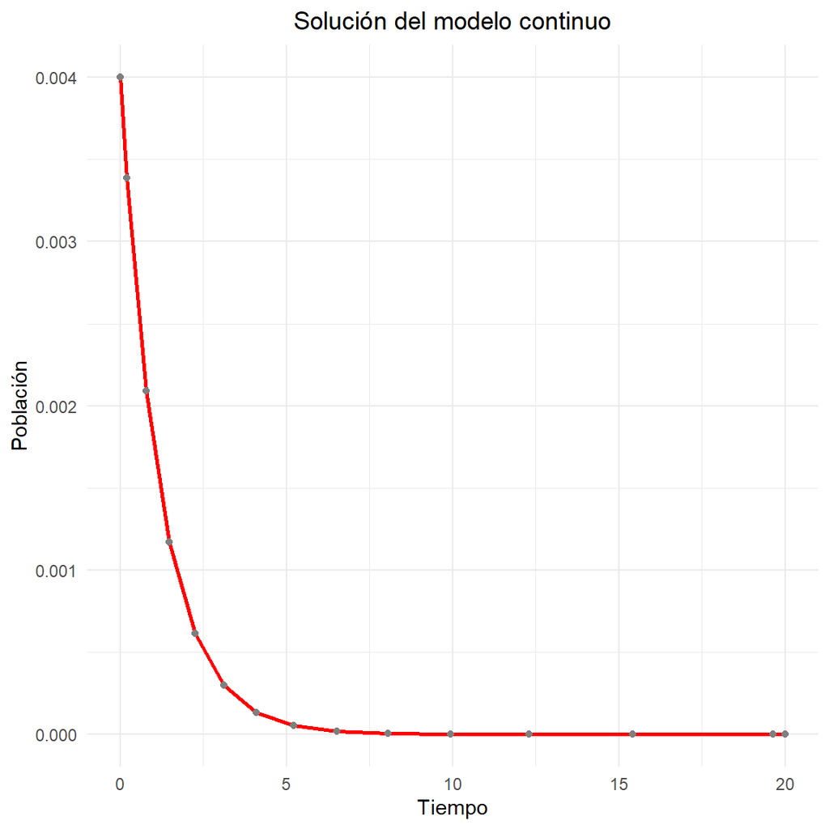

```r
sol %>%
  as_tibble() %>%
  ggplot(aes(x = t, y = y)) +
  geom_line(color = "red", size = 1) +
  geom_point(color = "gray50") +
  labs(title = "Solución del modelo continuo", x = "Tiempo", y = "Población") +
  theme_minimal() +
  theme(plot.title = element_text(hjust = 0.5))
```

## Avanzado

Necesitaremos algunas funciones auxiliares:

```r
library(dplyr)
library(purrr)
library(tibble)

library(ggplot2)
```

Podemos ahora repetir este procedimiento para varias condiciones iniciales, empleando un bucle `for` y guardando toda la información en el mismo `tibble`:

```r
f_ode <- function(t, y) -0.6 * y * log(200 / (y + 50))  # si no está definido aún

# Valores iniciales y nombres
y0s <- c(1/250, 1/100, 1/50, 1/10)
y_names <- paste0("y0_", seq_along(y0s))

# Lista vacía para almacenar data frames
sol_list <- list()

for (i in seq_along(y0s)) {
  y0_val <- y0s[i]
  nombre_curva <- y_names[i]

  new_sol <- ode45(f_ode, t0 = 0, tfinal = 20, y0 = y0_val) %>%
    as_tibble() %>%
    mutate(curva = nombre_curva)  # agregamos identificador

  sol_list[[i]] <- new_sol
}

# Unimos todas las soluciones en un solo data frame largo
sol_df <- bind_rows(sol_list)
sol_df %>% head()
```

```
## # A tibble: 6 × 3
##       t        y curva
##   <dbl>    <dbl> <chr>
## 1 0     0.004    y0_1
## 2 0.2   0.00339  y0_1
## 3 0.780 0.00209  y0_1
## 4 1.48  0.00117  y0_1
## 5 2.25  0.000614 y0_1
## 6 3.12  0.000299 y0_1
```

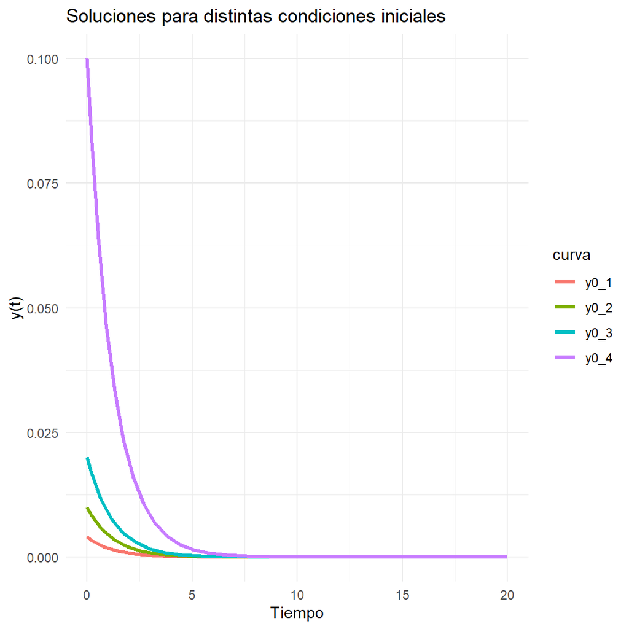

```r
ggplot(sol_df, aes(x = t, y = y, color = curva)) +
  geom_line(size = 1.2) +
  labs(title = "Soluciones para distintas condiciones iniciales",
       x = "Tiempo", y = "y(t)") +
  theme_minimal()
```